# Statistics Homework 11

B08705034 施芊羽 資管二

All the answers of this homework are rounded to the ten-thousandth if not be written.

```python
from matplotlib import pyplot as plt
%matplotlib inline
# 設定圖形大小; DPI越大圖越大
plt.rcParams["figure.dpi"] = 150
import seaborn as sns
import pandas as pd
import numpy as np
import scipy.stats as stats
import statsmodels.api as sm
import statsmodels.stats.api as sms
import statsmodels.formula.api as smf
import math as math
import statistics
from ete3 import Tree, faces, TreeStyle, TextFace, NodeStyle
from scipy.stats import binom
```

## Chapter 11

### 11.5

- $H_0$: The plane is on fire.
- $H_1$: The plane is not on fire. ##### Type of errors:
- Type I: The plane is on fire but the pilot chose not to land immediately:
  - Result: Several death and injuries.
- Type II: The plane is not on fire but the pilot chose to land immediately:
  - Result: The waste of money and time of the suddenly landing as well as the damage to the plane caused by immediately-landing.

If I'm the pilot of the plane, I'll choose to land immediately. Since the death and injuries are more difficult to recover and make up than the money and time wasted due to pre-landing, the decision to land immediately will be better than continuing flying.

### 11.22

#### a.

```python
m = 190
std = 50
n = 9
h0_mean = 200
zstat = (m - h0_mean) / (std / (n ** 0.5))
print(f"z = {zstat:.4f}")

p_onetail= stats.norm.cdf(zstat)
print(f"p-value (one-tail) = {p_onetail:.4f}")
```

```
z = -0.6000
p-value (one-tail) = 0.2743
```

#### b.

```python
m = 190
std = 30
n = 9
h0_mean = 200
zstat = (m - h0_mean) / (std / (n ** 0.5))
print(f"z = {zstat:.4f}")

p_onetail= stats.norm.cdf(zstat)
print(f"p-value (one-tail) = {p_onetail:.4f}")
```

```
z = -1.0000
p-value (one-tail) = 0.1587
```

#### c.

```python
m = 190
std = 10
n = 9
h0_mean = 200
zstat = (m - h0_mean) / (std / (n ** 0.5))
print(f"z = {zstat:.4f}")

p_onetail= stats.norm.cdf(zstat)
print(f"p-value (one-tail) = {p_onetail:.4f}")
```

```
z = -3.0000
p-value (one-tail) = 0.0013
```

#### d.

When the standard deviation decreases, the value of the test statistics and its p-value will both decrease.

### 11.39

```python
df_c11_39 = pd.read_excel("Xr11-39.xlsx")
n = df_c11_39["Times"].count()
m =  df_c11_39["Times"].mean()
std = 8
h0_mean = 36

p_onetail= stats.norm.cdf(zstat)
print(f"p-value (one-tail) = {p_onetail:.4f}")
```

```
p-value (one-tail) = 0.0013
```

The p-value of the test is 0.0013, which tells us that there is overwhelming evidence to infer that the alternative hypothesis is true.

### 11.53

```python
df_c11_53 = pd.read_excel("Xr11-53.xlsx")
n = df_c11_53["Strokes"].count()
m =  df_c11_53["Strokes"].mean()
print("Sample mean=", m)
std = 2
h0_mean = 5
siglevel = 0.1

p_onetail= 1 - stats.norm.cdf(zstat)
print(f"p-value (one-tail) = {p_onetail:.4f}")
```

[output not shown]

The $p-value = 0.0548 < \alpha = 0.1$, we judge the p-value is small enough to reject the null hypothesis.

### 11.54

```python
df_c11_54 = pd.read_excel("Xr11-54.xlsx")
n = df_c11_54["Minutes"].count()
m =  df_c11_54["Minutes"].mean()
print("Sample mean=", m)
std = 8
h0_mean = 32

zstat = (m - h0_mean) / (std / (n ** 0.5))
print(f"z = {zstat:.4f}")

p_onetail= stats.norm.cdf(zstat)
print(f"p-value (one-tail) = {p_onetail:.4f}")
```

```
Sample mean= 29.918181818181818
z = -2.7293
p-value (one-tail) = 0.0032
```

Yes, we can tell that the test is highly significant since $p-value = 0.0032 \lt 0.01$ and there is a decrease in the mean time away from their desks. Type I error would occur when the new no-powerful exhausts are not useful, the cost of it will be greater than the type II error that they are useful but we don't install them. Because that the $p-value$ is less than $.01$, we can say that there is overwhelming evidence to infer that the alternative hyopothesis is true and we surely save the cost.

### 11.60

```python
h0_mean = 200
n = 100
std = 10
alpha = 0.05
zcv = stats.norm.ppf(1 - alpha / 2)

print(f"Z critical value = {zcv:.4f}")
lcl = h0_mean - zcv * std / (n ** 0.5)
ucl = h0_mean + zcv * std / (n ** 0.5)
print(f"LCL = {lcl:.4f}, UCL = {ucl:.4f}")
h1_mean = 203
zl = (lcl - h1_mean) / (std / (n ** 0.5))
p = stats.norm.cdf(zl)
z2 = (ucl - h1_mean) / (std / (n ** 0.5))
p = p + stats.norm.cdf(z2)
print(f"P(typeII) = {p:.6f}")
```

```
Z critical value = 1.9600
LCL = 198.0400, UCL = 201.9600
P(typeII) = 0.149162
```

### 11.65

#### a.

```python
h0_mean = 40
n = 25
std = 5
alpha = 0.05
zcv = -stats.norm.ppf(1 - alpha)
xcv = h0_mean + zcv * std / (n ** 0.5)
print(f"X critical value = {xcv:.4f}")
h1_mean = 37
z = (xcv - h1_mean) / (std / (n ** 0.5))
p = 1 - stats.norm.cdf(z)
print(f"P(typeII) = {p:.4f}")
```

```
X critical value = 38.3551
P(typeII) = 0.0877
```

#### b.

```python
alpha = 0.15
zcv = -stats.norm.ppf(1 - alpha)
xcv = h0_mean + zcv * std / (n ** 0.5)
print(f"X critical value = {xcv:.4f}")
h1_mean = 37
z = (xcv - h1_mean) / (std / (n ** 0.5))
p = 1 - stats.norm.cdf(z)
print(f"P(typeII) = {p:.4f}")
```

```
X critical value = 38.9636
P(typeII) = 0.0248
```

#### c.

When $\alpha$ increases, $\beta$ will decrease.

### 11.70

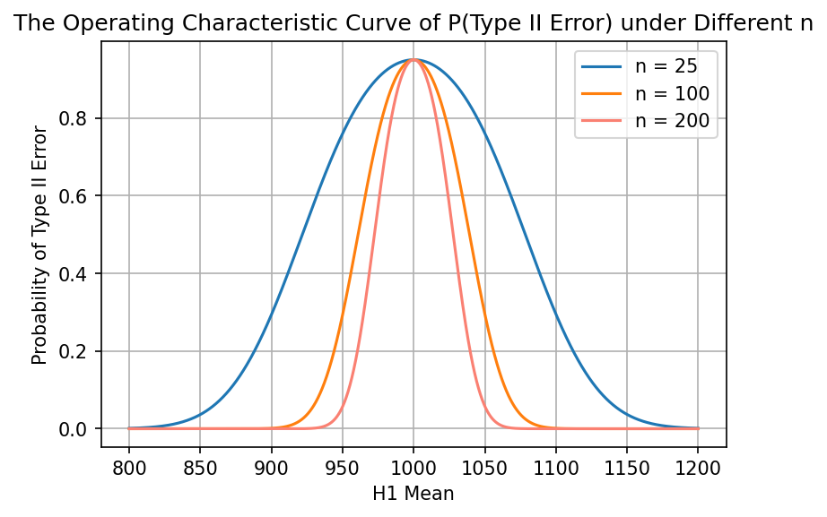

```python
h0_mean = 1000
n = 25
std = 200
alpha = 0.05
zcv = stats.norm.ppf(1 - alpha / 2)
ucl = h0_mean + zcv * std / (n ** 0.5)
lcl = h0_mean - zcv * std / (n ** 0.5)
mean_vec = np.arange(800, 1200, 0.1)
beta_vec = np.zeros(mean_vec.shape[0])
for i, h1_mean in enumerate(mean_vec):
    z = (lcl - h1_mean) / (std / (n ** 0.5))
    p = -stats.norm.cdf(z)
    z = (ucl - h1_mean) / (std / (n ** 0.5))
    p = p + stats.norm.cdf(z)
    beta_vec[i] = p

_ = plt.plot(mean_vec, beta_vec)

n = 100
zcv = stats.norm.ppf(1 - alpha / 2)
ucl = h0_mean + zcv * std / (n ** 0.5)
lcl = h0_mean - zcv * std / (n ** 0.5)
mean_vec = np.arange(800, 1200, 0.1)
beta_vec = np.zeros(mean_vec.shape[0])
for i, h1_mean in enumerate(mean_vec):
    z = (lcl - h1_mean) / (std / (n ** 0.5))
    p = -stats.norm.cdf(z)
    z = (ucl - h1_mean) / (std / (n ** 0.5))
    p = p + stats.norm.cdf(z)
    beta_vec[i] = p
_ = plt.plot(mean_vec, beta_vec)

n = 200
zcv = stats.norm.ppf(1 - alpha / 2)
ucl = h0_mean + zcv * std / (n ** 0.5)
lcl = h0_mean - zcv * std / (n ** 0.5)
mean_vec = np.arange(800, 1200, 0.1)
beta_vec = np.zeros(mean_vec.shape[0])
for i, h1_mean in enumerate(mean_vec):
    z = (lcl - h1_mean) / (std / (n ** 0.5))
    p = -stats.norm.cdf(z)
    z = (ucl - h1_mean) / (std / (n ** 0.5))
    p = p + stats.norm.cdf(z)
    beta_vec[i] = p
_ = plt.plot(mean_vec, beta_vec, color = "salmon")

plt.legend(["n = 25", "n = 100", "n = 200"])
plt.xlabel("H1 Mean")
plt.ylabel("Probability of Type II Error")
plt.title("The Operating Characteristic Curve of P(Type II Error) under Different n")
plt.grid(True)
```

### 11.75

```python
df_c11_75 = pd.read_excel("Xr11-51.xlsx")
h0_mean = 100
n = df_c11_75["Pedestrians"].count()
std = 16
alpha = 0.01
zcv = stats.norm.ppf(1 - alpha)
xcv = h0_mean + zcv * std / (n ** 0.5)
print(f"X critical value = {xcv:.4f}")
h1_mean = 104
z = (xcv - h1_mean) / (std / (n ** 0.5))
p = stats.norm.cdf(z)
print(f"P(typeII) = {p:.4f}")
```

```
X critical value = 105.8852
P(typeII) = 0.7719
```

The power of the test is $1 - \beta = 0.2281$, the franchiser can try to increase the sample size to lower the probability of type 2 error.